# Sprint 8: Supervised Learning

# Preliminaries

```python
# Load libraries

import pandas as pd
import numpy as np
from matplotlib import pyplot as plt

from sklearn.model_selection import train_test_split
from sklearn.preprocessing import StandardScaler
from sklearn.utils import shuffle

from sklearn.tree import DecisionTreeClassifier
from sklearn.ensemble import RandomForestClassifier
from sklearn.linear_model import LogisticRegression

from sklearn.metrics import f1_score
from sklearn.metrics import roc_curve
from sklearn.metrics import roc_auc_score
```

```python
# Load data

df_churn = pd.read_csv('/datasets/Churn.csv')
```

The goal of this project is to train a model for predicting which customers are likely to leave Beta Bank so efforts can be made to retain them. I will evaluate classification models trained on demographic and bank records. The final model must have an F1 score exceeding 0.59.

# Examine the Data

```python
# Examine the df_churn dataframe

display(df_churn.info())
print()
df_churn
```

```
<class 'pandas.core.frame.DataFrame'>
RangeIndex: 10000 entries, 0 to 9999
Data columns (total 14 columns):
 #   Column           Non-Null Count  Dtype
---  ------           --------------  -----
 0   RowNumber        10000 non-null  int64
 1   CustomerId       10000 non-null  int64
 2   Surname          10000 non-null  object
 3   CreditScore      10000 non-null  int64
 4   Geography        10000 non-null  object
 5   Gender           10000 non-null  object
 6   Age              10000 non-null  int64
 7   Tenure           9091 non-null   float64
 8   Balance          10000 non-null  float64
 9   NumOfProducts    10000 non-null  int64
 10  HasCrCard        10000 non-null  int64
 11  IsActiveMember   10000 non-null  int64
 12  EstimatedSalary  10000 non-null  float64
 13  Exited           10000 non-null  int64
dtypes: float64(3), int64(8), object(3)
memory usage: 1.1+ MB
```

```
None
```

|  | RowNumber | CustomerId | Surname | CreditScore | Geography | Gender | Age | Tenure | Balance | NumOfProducts | HasCrCard | IsActiveMember | EstimatedSalary | Exited |
| --- | --- | --- | --- | --- | --- | --- | --- | --- | --- | --- | --- | --- | --- | --- |
| 0 | 1 | 15634602 | Hargrave | 619 | France | Female | 42 | 2.0 | 0.00 | 1 | 1 | 1 | 101348.88 | 1 |
| 1 | 2 | 15647311 | Hill | 608 | Spain | Female | 41 | 1.0 | 83807.86 | 1 | 0 | 1 | 112542.58 | 0 |
| 2 | 3 | 15619304 | Onio | 502 | France | Female | 42 | 8.0 | 159660.80 | 3 | 1 | 0 | 113931.57 | 1 |
| 3 | 4 | 15701354 | Boni | 699 | France | Female | 39 | 1.0 | 0.00 | 2 | 0 | 0 | 93826.63 | 0 |
| 4 | 5 | 15737888 | Mitchell | 850 | Spain | Female | 43 | 2.0 | 125510.82 | 1 | 1 | 1 | 79084.10 | 0 |
| ... | ... | ... | ... | ... | ... | ... | ... | ... | ... | ... | ... | ... | ... | ... |
| 9995 | 9996 | 15606229 | Obijiaku | 771 | France | Male | 39 | 5.0 | 0.00 | 2 | 1 | 0 | 96270.64 | 0 |
| 9996 | 9997 | 15569892 | Johnstone | 516 | France | Male | 35 | 10.0 | 57369.61 | 1 | 1 | 1 | 101699.77 | 0 |
| 9997 | 9998 | 15584532 | Liu | 709 | France | Female | 36 | 7.0 | 0.00 | 1 | 0 | 1 | 42085.58 | 1 |
| 9998 | 9999 | 15682355 | Sabbatini | 772 | Germany | Male | 42 | 3.0 | 75075.31 | 2 | 1 | 0 | 92888.52 | 1 |
| 9999 | 10000 | 15628319 | Walker | 792 | France | Female | 28 | NaN | 130142.79 | 1 | 1 | 0 | 38190.78 | 0 |

10000 rows × 14 columns

```python
# Create a function to examine columns

def histo(df, column):
    if (len(df[column].unique()) < 25): bins = len(df[column].unique())
    else: bins = 25

    display(df[column].describe())
    plt.hist(df[column], bins=bins)
    plt.xlabel(column)
    plt.ylabel('Number of Observations')
    plt.title(f'Histogram for {column}')
    plt.show()
```

```
count    10000.00000
mean      5000.50000
std       2886.89568
min          1.00000
25%       2500.75000
50%       5000.50000
75%       7500.25000
max      10000.00000
Name: RowNumber, dtype: float64
```

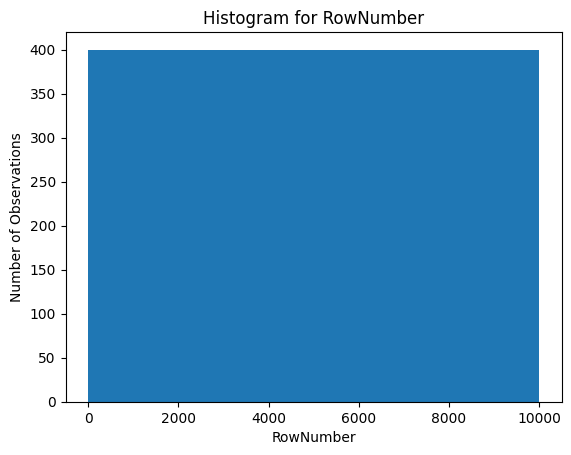

```
count    1.000000e+04
mean     1.569094e+07
std      7.193619e+04
min      1.556570e+07
25%      1.562853e+07
50%      1.569074e+07
75%      1.575323e+07
max      1.581569e+07
Name: CustomerId, dtype: float64
```

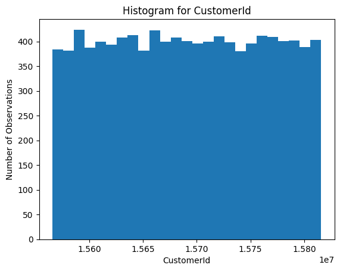

```
count     10000
unique     2932
top       Smith
freq         32
Name: Surname, dtype: object
```

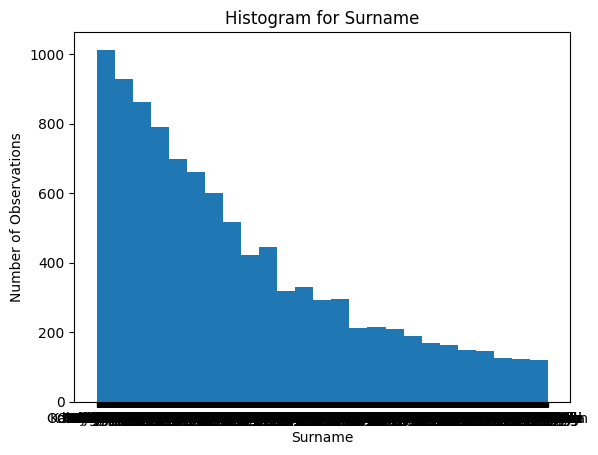

```
count    10000.000000
mean       650.528800
std         96.653299
min        350.000000
25%        584.000000
50%        652.000000
75%        718.000000
max        850.000000
Name: CreditScore, dtype: float64
```

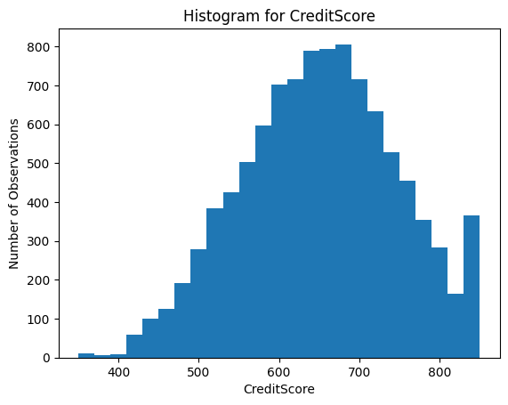

```
count      10000
unique         3
top       France
freq        5014
Name: Geography, dtype: object
```

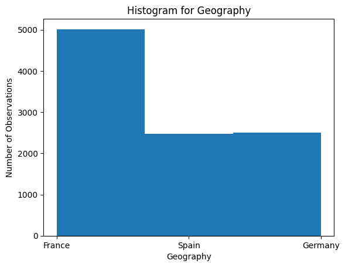

```
count     10000
unique        2
top        Male
freq       5457
Name: Gender, dtype: object
```

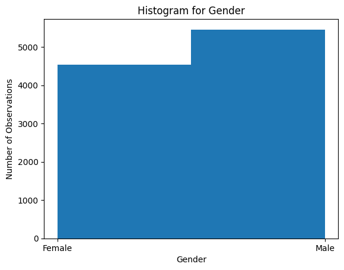

```
count    10000.000000
mean        38.921800
std         10.487806
min         18.000000
25%         32.000000
50%         37.000000
75%         44.000000
max         92.000000
Name: Age, dtype: float64
```

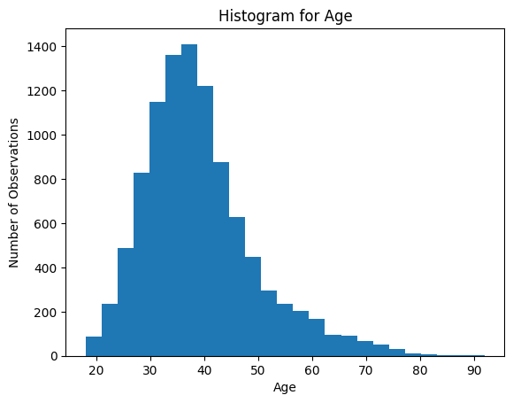

```
count    9091.000000
mean        4.997690
std         2.894723
min         0.000000
25%         2.000000
50%         5.000000
75%         7.000000
max        10.000000
Name: Tenure, dtype: float64
```

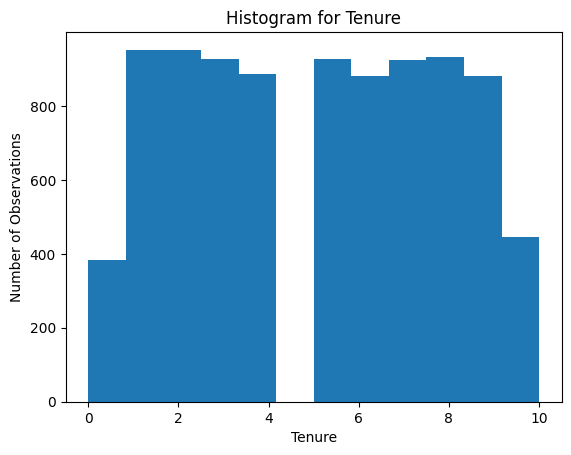

```
count     10000.000000
mean      76485.889288
std       62397.405202
min           0.000000
25%           0.000000
50%       97198.540000
75%      127644.240000
max      250898.090000
Name: Balance, dtype: float64
```

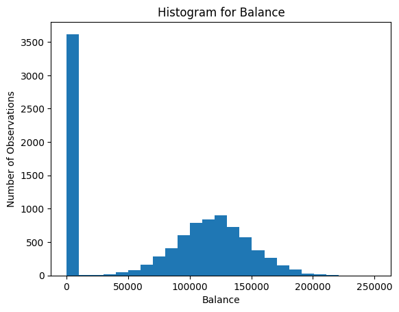

```
count    10000.000000
mean         1.530200
std          0.581654
min          1.000000
25%          1.000000
50%          1.000000
75%          2.000000
max          4.000000
Name: NumOfProducts, dtype: float64
```

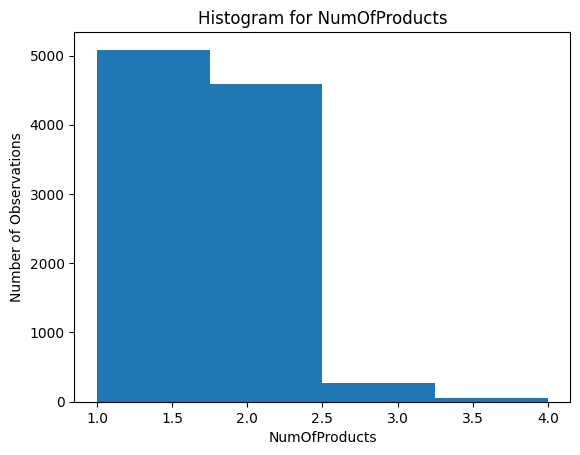

```
count    10000.00000
mean         0.70550
std          0.45584
min          0.00000
25%          0.00000
50%          1.00000
75%          1.00000
max          1.00000
Name: HasCrCard, dtype: float64
```

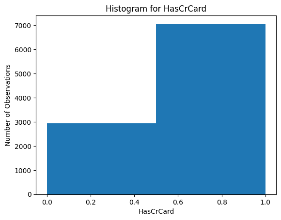

```
count    10000.000000
mean         0.515100
std          0.499797
min          0.000000
25%          0.000000
50%          1.000000
75%          1.000000
max          1.000000
Name: IsActiveMember, dtype: float64
```

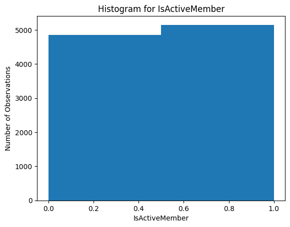

```
count     10000.000000
mean     100090.239881
std       57510.492818
min          11.580000
25%       51002.110000
50%      100193.915000
75%      149388.247500
max      199992.480000
Name: EstimatedSalary, dtype: float64
```

[2 more figures not shown]

```python
# Examine all columns from df_churn

for column in df_churn.columns:
    histo(df_churn, column)
    print()
```

```python
# Examine some columns further

print("Tenure values:", df_churn['Tenure'].unique())
print("NumOfProducts values:", df_churn['NumOfProducts'].unique())
print("Balance = 0:", len(df_churn[df_churn['Balance'] == 0]))
print("Exited = 0:", len(df_churn[df_churn['Exited'] == 0]))
```

```
Tenure values: [ 2.  1.  8.  7.  4.  6.  3. 10.  5.  9.  0. nan]
NumOfProducts values: [1 3 2 4]
Balance = 0: 3617
Exited = 0: 7963
```

```python
# Examine missing values for the Tenure feature

missing = df_churn[df_churn['Tenure'].isna()]
not_missing = df_churn[~df_churn['Tenure'].isna()]

mean_missing = []
mean_not_missing = []
columns = []
for column in missing.columns:
    if missing[column].dtype != 'object':
        mean_missing.append(missing[column].mean())
        mean_not_missing.append(not_missing[column].mean())
        columns.append(column)

display(pd.DataFrame({'column': columns,
                      'mean missing': mean_missing,
                      'mean not missing': mean_not_missing
                    }).dropna().round(2))
```

|  | column | mean missing | mean not missing |
| --- | --- | --- | --- |
| 0 | RowNumber | 4866.39 | 5013.91 |
| 1 | CustomerId | 15689814.58 | 15691053.16 |
| 2 | CreditScore | 648.45 | 650.74 |
| 3 | Age | 38.65 | 38.95 |
| 5 | Balance | 76117.34 | 76522.74 |
| 6 | NumOfProducts | 1.53 | 1.53 |
| 7 | HasCrCard | 0.71 | 0.70 |
| 8 | IsActiveMember | 0.51 | 0.52 |
| 9 | EstimatedSalary | 99180.39 | 100181.21 |
| 10 | Exited | 0.20 | 0.20 |

The data look good overall. I will change the data type of the Tenure column from float to integer but the rest are appropriate.

I think RowNumber, CustomerId, and Surname are irrelevant for the purposes of modeling bank churn. The first two could contain useful information if they were assigned chronologically or by some other meaningful convention, but without more information about that, I will exclude them. Including arbitrary or irrelevant features in a model can lead to overfitting and distorted interpretations.

Five columns (Geography, Gender, HasCrCard, IsActiveMember, and Exited) are categorical with only a few values. Four columns (CreditScore, Age, Balance, and EstimatedSalary) are continuous, with approximately normal distributions for CreditScore and Age and a nearly uniform distribution for EstimatedSalary. Balance is also normally distributed except for an excess of zeros representing 36% of the sample. In some circumstances, I might split that into two columns (HasBalance and BalanceAmount) to separate the processes at work, but that probably is not necessary here. Two columns (Tenure and NumberOfProducts) are discrete and restricted in range to a dozen or fewer values but they are ordinal, so numeric labels are appropriate. None of the classification models I will use are particularly sensitive to normality assumptions, so these data should be fine.

The only missing values are in the Tenure column, representing 9% of the sample. I found no obvious pattern in the means of missing and non-missing rows. If the values are missing at random, filling them with the mean or median might make sense. If some accounts have no period of maturation, zeros might be more appropriate. If some accounts have no fixed deposits at all, filling in any value might be misleading. For example, owning no car is not equivalent to owning one with a zero-liter engine or even an average-sized engine. Without a better understanding of what Tenure actually means, I am hesitant to guess at the best imputation method. Given the large size of the sample, I think losing 9% is preferable to introducing questionable data, so I will drop it.

Categorical columns HasCrCard, IsActiveMember, and Exited are already in a binary (0 or 1) format, but Gender and Geography need to be encoded numerically. With just 2 and 3 categories each, One-Hot Encoding is suitable for both columns. Numerical columns CreditScore, Age, Tenure, Balance, NumOfProducts, and EstimatedSalary all need to be standardized. These transformations are necessary for the classification algorithms to appropriately weight the data.

The Exited column, which will be the target for modeling, has a considerable imbalance with 80% of values being 0 and the rest 1. That will require some adjustment during model optimization but not yet.

To summarize, I will drop from the training data the RowNumber, CustomerId, and Surname columns and the rows with missing values in the Tenure column. I will also change the Tenure column's data type from float to integer, apply One-Hot Encoding to Gender and Geography, and standardize CreditScore, Age, Tenure, Balance, NumOfProducts, and EstimatedSalary. With that done, I will split the data into train, validate, and test sets and proceed to modeling.

# Prepare the Data

```python
# Drop RowNumber, CustomerId, and Surname columns and missing values from the Tenure column

df_churn = df_churn.drop(['RowNumber', 'CustomerId', 'Surname'], axis=1).dropna()

df_churn.info()
```

```
<class 'pandas.core.frame.DataFrame'>
Int64Index: 9091 entries, 0 to 9998
Data columns (total 11 columns):
 #   Column           Non-Null Count  Dtype
---  ------           --------------  -----
 0   CreditScore      9091 non-null   int64
 1   Geography        9091 non-null   object
 2   Gender           9091 non-null   object
 3   Age              9091 non-null   int64
 4   Tenure           9091 non-null   float64
 5   Balance          9091 non-null   float64
 6   NumOfProducts    9091 non-null   int64
 7   HasCrCard        9091 non-null   int64
 8   IsActiveMember   9091 non-null   int64
 9   EstimatedSalary  9091 non-null   float64
 10  Exited           9091 non-null   int64
dtypes: float64(3), int64(6), object(2)
memory usage: 852.3+ KB
```

```python
# Change Tenure column to integer data type

def float_to_int(df, column):
    if np.all(df[column] == df[column].astype(int)):
        print(f"Data from the {column} column are identical as float and integer types, so conversion is safe.")
        df[column] = df[column].astype(int)
    else:
        print(f"Data from the {column} column are not identical as float and integer types, so conversion is NOT safe.")

float_to_int(df_churn, 'Tenure')

print()
print(df_churn.info())
```

```
Data from the Tenure column are identical as float and integer types, so conversion is safe.

<class 'pandas.core.frame.DataFrame'>
Int64Index: 9091 entries, 0 to 9998
Data columns (total 11 columns):
 #   Column           Non-Null Count  Dtype
---  ------           --------------  -----
 0   CreditScore      9091 non-null   int64
 1   Geography        9091 non-null   object
 2   Gender           9091 non-null   object
 3   Age              9091 non-null   int64
 4   Tenure           9091 non-null   int64
 5   Balance          9091 non-null   float64
 6   NumOfProducts    9091 non-null   int64
 7   HasCrCard        9091 non-null   int64
 8   IsActiveMember   9091 non-null   int64
 9   EstimatedSalary  9091 non-null   float64
 10  Exited           9091 non-null   int64
dtypes: float64(2), int64(7), object(2)
memory usage: 852.3+ KB
None
```

```python
# Apply One-Hot Encoding to Gender and Geography columns
# Standardize CreditScore, Age, Tenure, Balance, NumOfProducts, and EstimatedSalary columns

df_churn = pd.get_dummies(df_churn, drop_first=True)

numeric = ['CreditScore', 'Age', 'Tenure', 'Balance', 'NumOfProducts', 'EstimatedSalary']
scaler = StandardScaler()
scaler.fit(df_churn[numeric])
df_churn[numeric] = scaler.transform(df_churn[numeric])

display(df_churn)
```

|  | CreditScore | Age | Tenure | Balance | NumOfProducts | HasCrCard | IsActiveMember | EstimatedSalary | Exited | Geography_Germany | Geography_Spain | Gender_Male |
| --- | --- | --- | --- | --- | --- | --- | --- | --- | --- | --- | --- | --- |
| 0 | -0.329200 | 0.289040 | -1.035627 | -1.227780 | -0.912601 | 1 | 1 | 0.020264 | 1 | 0 | 0 | 0 |
| 1 | -0.443301 | 0.194298 | -1.381103 | 0.116887 | -0.912601 | 0 | 1 | 0.214527 | 0 | 0 | 1 | 0 |
| 2 | -1.542828 | 0.289040 | 1.037224 | 1.333920 | 2.529911 | 1 | 0 | 0.238632 | 1 | 0 | 0 | 0 |
| 3 | 0.500631 | 0.004815 | -1.381103 | -1.227780 | 0.808655 | 0 | 0 | -0.110281 | 0 | 0 | 0 | 0 |
| 4 | 2.066937 | 0.383782 | -1.035627 | 0.785996 | -0.912601 | 1 | 1 | -0.366132 | 0 | 0 | 1 | 0 |
| ... | ... | ... | ... | ... | ... | ... | ... | ... | ... | ... | ... | ... |
| 9994 | 1.548293 | -0.942603 | -1.035627 | -1.227780 | 0.808655 | 0 | 0 | 1.173038 | 0 | 0 | 0 | 0 |
| 9995 | 1.247479 | 0.004815 | 0.000798 | -1.227780 | 0.808655 | 1 | 0 | -0.067866 | 0 | 0 | 0 | 1 |
| 9996 | -1.397607 | -0.374153 | 1.728174 | -0.307305 | -0.912601 | 1 | 1 | 0.026354 | 0 | 0 | 0 | 1 |
| 9997 | 0.604360 | -0.279411 | 0.691748 | -1.227780 | -0.912601 | 0 | 1 | -1.008227 | 1 | 0 | 0 | 0 |
| 9998 | 1.257852 | 0.289040 | -0.690152 | -0.023223 | 0.808655 | 1 | 0 | -0.126562 | 1 | 1 | 0 | 1 |

9091 rows × 12 columns

```python
# Split the data into training, validation, and test sets

features = df_churn.drop('Exited', axis=1)
target = df_churn['Exited']

features_train, features_test, target_train, target_test = train_test_split(features, target, test_size=.2, random_state=12345)
features_train, features_valid, target_train, target_valid = train_test_split(features_train, target_train, test_size=.25, random_state=12345)

print(f"Training set size: {len(features_train)}, {100*len(features_train)/len(df_churn):.0f}%")
print(f"Validation set size: {len(features_valid)}, {100*len(features_valid)/len(df_churn):.0f}%")
print(f"Test set size: {len(features_test)}, {100*len(features_test)/len(df_churn):.0f}%")
```

```
Training set size: 5454, 60%
Validation set size: 1818, 20%
Test set size: 1819, 20%
```

# Model Data

```
0    0.794829
1    0.205171
Name: Exited, dtype: float64
```

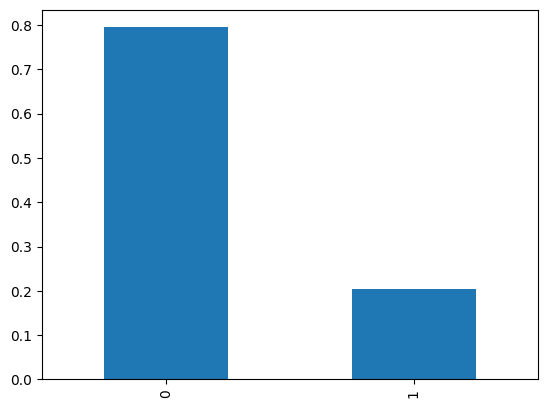

```python
# Examine the balance of classes

class_frequency = target_train.value_counts(normalize=True)

print(class_frequency)
class_frequency.plot(kind='bar')
```

There is a severe class imbalance on the target feature Exited with four times as many 0s (has not exited) as 1s (has exited). Something will need to be done about that, but I will try some models first.

```python
# Train models without taking class imbalance into account

dt_model = DecisionTreeClassifier(random_state=12345)
rf_model = RandomForestClassifier(random_state=12345)
lr_model = LogisticRegression(random_state=12345, solver='liblinear')
rng = np.random.default_rng(seed=12345)

dt_model.fit(features_train, target_train)
rf_model.fit(features_train, target_train)
lr_model.fit(features_train, target_train)

f1_imbalanced = []
for model in [dt_model, rf_model, lr_model]:
    f1_train = f1_score(target_train, model.predict(features_train))
    f1_valid = f1_score(target_valid, model.predict(features_valid))
    f1_imbalanced.append(f1_valid)
    print(str(model).split('(')[0])
    print("F1 score on a training set: ", f1_train)
    print("F1 score on a validation set: ", f1_valid)

print("Random Model")
print("F1 score on a training set: ", f1_score(target_train, rng.choice([0, 1], size=len(features_train))))
print("F1 score on a validation set: ", f1_score(target_valid, rng.choice([0, 1], size=len(features_valid))))
```

```
DecisionTreeClassifier
F1 score on a training set:  1.0
F1 score on a validation set:  0.4905149051490515
RandomForestClassifier
F1 score on a training set:  1.0
F1 score on a validation set:  0.5507745266781411
LogisticRegression
F1 score on a training set:  0.2864828513786146
F1 score on a validation set:  0.3004115226337448
Random Model
F1 score on a training set:  0.2913941930421135
F1 score on a validation set:  0.282574568288854
```

Without taking the class imbalance into account, the models were not very good. The logistic regression model was no better than randomly choosing a class. Decision tree and random forest classification models achieved perfect F1 scores of 1 for the training data, but neither surpassed the project's 0.59 threshold for the validation set. The random forest classifier (F1 = 0.55) outperformed the simpler decision tree classifier (F1 = 0.49) and logistic regression (F1 = 0.30). The class imbalance needs to be addressed for better models. I will try a class weight adjustment and upsampling.

```python
# Train the models with a class weight adjustment

dt_model = DecisionTreeClassifier(random_state=12345, class_weight='balanced')
rf_model = RandomForestClassifier(random_state=12345, class_weight='balanced')
lr_model = LogisticRegression(random_state=12345, solver='liblinear', class_weight='balanced')
rng = np.random.default_rng(seed=12345)

dt_model.fit(features_train, target_train)
rf_model.fit(features_train, target_train)
lr_model.fit(features_train, target_train)

f1_weighted = []
for model in [dt_model, rf_model, lr_model]:
    f1_train = f1_score(target_train, model.predict(features_train))
    f1_valid = f1_score(target_valid, model.predict(features_valid))
    f1_weighted.append(f1_valid)
    print(str(model).split('(')[0])
    print("F1 score on a training set: ", f1_train)
    print("F1 score on a validation set: ", f1_valid)
```

```
DecisionTreeClassifier
F1 score on a training set:  1.0
F1 score on a validation set:  0.489010989010989
RandomForestClassifier
F1 score on a training set:  1.0
F1 score on a validation set:  0.5283687943262412
LogisticRegression
F1 score on a training set:  0.4984025559105431
F1 score on a validation set:  0.49506903353057197
```

```python
# Upsample the data

def upsample(features, target, repeat):
    features_zeros = features[target == 0]
    features_ones = features[target == 1]
    target_zeros = target[target == 0]
    target_ones = target[target == 1]

    features_upsampled = pd.concat([features_zeros] + [features_ones] * repeat)
    target_upsampled = pd.concat([target_zeros] + [target_ones] * repeat)

    features_upsampled, target_upsampled = shuffle(
        features_upsampled, target_upsampled, random_state=12345)

    return features_upsampled, target_upsampled

features_upsampled, target_upsampled = upsample(features_train, target_train, 4)

print("Upsampled Class Frequencies:")
display(target_upsampled.value_counts(normalize=True))
```

```
Upsampled Class Frequencies:
```

```
1    0.508001
0    0.491999
Name: Exited, dtype: float64
```

```python
# Train the models with upsampled data

dt_model = DecisionTreeClassifier(random_state=12345)
rf_model = RandomForestClassifier(random_state=12345)
lr_model = LogisticRegression(random_state=12345, solver='liblinear')
rng = np.random.default_rng(seed=12345)

dt_model.fit(features_upsampled, target_upsampled)
rf_model.fit(features_upsampled, target_upsampled)
lr_model.fit(features_upsampled, target_upsampled)

f1_upsampled = []
for model in [dt_model, rf_model, lr_model]:
    f1_train = f1_score(target_train, model.predict(features_train))
    f1_valid = f1_score(target_valid, model.predict(features_valid))
    f1_upsampled.append(f1_valid)
    print(str(model).split('(')[0])
    print("F1 score on a training set: ", f1_train)
    print("F1 score on a validation set: ", f1_valid)
```

```
DecisionTreeClassifier
F1 score on a training set:  1.0
F1 score on a validation set:  0.4945652173913044
RandomForestClassifier
F1 score on a training set:  1.0
F1 score on a validation set:  0.5882352941176471
LogisticRegression
F1 score on a training set:  0.4949748743718594
F1 score on a validation set:  0.4956605593056895
```

```python
# Summarize attempts to address class imbalance

print("F1 Scores for Validation Data:")
display(pd.DataFrame({'model': ['DecisionTreeClassifier', 'RandomForestClassifier', 'LogisticRegression'],
                      'imbalanced': f1_imbalanced,
                      'weighted': f1_weighted,
                      'upsampled': f1_upsampled
                    }).dropna().round(4))
```

```
F1 Scores for Validation Data:
```

|  | model | imbalanced | weighted | upsampled |
| --- | --- | --- | --- | --- |
| 0 | DecisionTreeClassifier | 0.4905 | 0.4890 | 0.4946 |
| 1 | RandomForestClassifier | 0.5508 | 0.5284 | 0.5882 |
| 2 | LogisticRegression | 0.3004 | 0.4951 | 0.4957 |

I addressed the class imbalance in two ways: specifying the class_weight parameter and upsampling the data. Both strategies increased the logistic regression models' F1 scores to just under 0.5, on par with the decision tree classifier. Whereas weighting slightly decreased F1 scores for the decision tree and random forest classifiers, upsampling slightly increased them. The random forest classifier was more affected by both strategies and it was the best performing model in every case. Its upscaled F1 score of 0.5882 was within rounding error of the project's threshold of 0.59. I will improve the upsampled random forest model further by optimizing parameters.

```python
# Find the best fittting upsampled random forest classifier model by varying estimators and depth

best_rf_model = None
best_rf_est = 0
best_rf_depth = 0
best_rf_result = 0
rf_results = []

for est in range(1, 31):
    for depth in range (1, 31):
        model = RandomForestClassifier(random_state=12345, n_estimators=est, max_depth=depth)
        model.fit(features_upsampled, target_upsampled)
        predictions_upsampled = model.predict(features_upsampled)
        predictions_valid = model.predict(features_valid)
        result_upsampled = f1_score(target_upsampled, predictions_upsampled)
        result_valid = f1_score(target_valid, predictions_valid)
        print(f'model estimators = {est}, depth = {depth}, training set accuracy = {result_upsampled:.4f}, validation set accuracy = {result_valid:.4f}')
        rf_results.append([est, depth, result_upsampled, result_valid])
        if result_valid > best_rf_result:
            best_rf_est = est
            best_rf_depth = depth
            best_rf_model = model
            best_rf_result = result_valid

rf_results = pd.DataFrame(rf_results, columns=['est', 'depth', 'result_upsampled', 'result_valid'])

print()
print("Best random forest model:")
print("Estimators:", best_rf_est)
print("Depth:", best_rf_depth)
print(f"F1: {best_rf_result:.4f}")
```

```
model estimators = 1, depth = 1, training set accuracy = 0.2489, validation set accuracy = 0.1845
model estimators = 1, depth = 2, training set accuracy = 0.5726, validation set accuracy = 0.4043
model estimators = 1, depth = 3, training set accuracy = 0.7306, validation set accuracy = 0.4720
model estimators = 1, depth = 4, training set accuracy = 0.7259, validation set accuracy = 0.5356
model estimators = 1, depth = 5, training set accuracy = 0.7360, validation set accuracy = 0.5193
model estimators = 1, depth = 6, training set accuracy = 0.7421, validation set accuracy = 0.5392
model estimators = 1, depth = 7, training set accuracy = 0.7679, validation set accuracy = 0.5182
model estimators = 1, depth = 8, training set accuracy = 0.7692, validation set accuracy = 0.5208
model estimators = 1, depth = 9, training set accuracy = 0.8093, validation set accuracy = 0.5202
model estimators = 1, depth = 10, training set accuracy = 0.8357, validation set accuracy = 0.5408
model estimators = 1, depth = 11, training set accuracy = 0.8539, validation set accuracy = 0.5073
model estimators = 1, depth = 12, training set accuracy = 0.8770, validation set accuracy = 0.4939
model estimators = 1, depth = 13, training set accuracy = 0.8893, validation set accuracy = 0.5028
model estimators = 1, depth = 14, training set accuracy = 0.9204, validation set accuracy = 0.4951
model estimators = 1, depth = 15, training set accuracy = 0.9372, validation set accuracy = 0.4713
model estimators = 1, depth = 16, training set accuracy = 0.9352, validation set accuracy = 0.4703
model estimators = 1, depth = 17, training set accuracy = 0.9571, validation set accuracy = 0.4830
model estimators = 1, depth = 18, training set accuracy = 0.9595, validation set accuracy = 0.4542
model estimators = 1, depth = 19, training set accuracy = 0.9646, validation set accuracy = 0.4851
model estimators = 1, depth = 20, training set accuracy = 0.9660, validation set accuracy = 0.4685
model estimators = 1, depth = 21, training set accuracy = 0.9630, validation set accuracy = 0.4778
model estimators = 1, depth = 22, training set accuracy = 0.9671, validation set accuracy = 0.5032
model estimators = 1, depth = 23, training set accuracy = 0.9655, validation set accuracy = 0.4667
model estimators = 1, depth = 24, training set accuracy = 0.9649, validation set accuracy = 0.4981
model estimators = 1, depth = 25, training set accuracy = 0.9649, validation set accuracy = 0.4981
model estimators = 1, depth = 26, training set accuracy = 0.9649, validation set accuracy = 0.4981
model estimators = 1, depth = 27, training set accuracy = 0.9649, validation set accuracy = 0.4981
model estimators = 1, depth = 28, training set accuracy = 0.9649, validation set accuracy = 0.4981
model estimators = 1, depth = 29, training set accuracy = 0.9649, validation set accuracy = 0.4981
model estimators = 1, depth = 30, training set accuracy = 0.9649, validation set accuracy = 0.4981
model estimators = 2, depth = 1, training set accuracy = 0.2489, validation set accuracy = 0.1845
model estimators = 2, depth = 2, training set accuracy = 0.6508, validation set accuracy = 0.5031
model estimators = 2, depth = 3, training set accuracy = 0.7388, validation set accuracy = 0.4979
model estimators = 2, depth = 4, training set accuracy = 0.7294, validation set accuracy = 0.5271
model estimators = 2, depth = 5, training set accuracy = 0.7531, validation set accuracy = 0.5297
model estimators = 2, depth = 6, training set accuracy = 0.7644, validation set accuracy = 0.5422
model estimators = 2, depth = 7, training set accuracy = 0.7698, validation set accuracy = 0.5061
model estimators = 2, depth = 8, training set accuracy = 0.8039, validation set accuracy = 0.5154
model estimators = 2, depth = 9, training set accuracy = 0.8399, validation set accuracy = 0.5288
model estimators = 2, depth = 10, training set accuracy = 0.8597, validation set accuracy = 0.5148
```

[output cut: 29 more lines]

```
model estimators = 3, depth = 10, training set accuracy = 0.8686, validation set accuracy = 0.5255
model estimators = 3, depth = 11, training set accuracy = 0.9132, validation set accuracy = 0.5595
model estimators = 3, depth = 12, training set accuracy = 0.9344, validation set accuracy = 0.5256
model estimators = 3, depth = 13, training set accuracy = 0.9529, validation set accuracy = 0.5404
model estimators = 3, depth = 14, training set accuracy = 0.9738, validation set accuracy = 0.5251
model estimators = 3, depth = 15, training set accuracy = 0.9745, validation set accuracy = 0.5289
model estimators = 3, depth = 16, training set accuracy = 0.9787, validation set accuracy = 0.5044
model estimators = 3, depth = 17, training set accuracy = 0.9860, validation set accuracy = 0.5183
model estimators = 3, depth = 18, training set accuracy = 0.9884, validation set accuracy = 0.4786
model estimators = 3, depth = 19, training set accuracy = 0.9879, validation set accuracy = 0.5241
model estimators = 3, depth = 20, training set accuracy = 0.9887, validation set accuracy = 0.5217
model estimators = 3, depth = 21, training set accuracy = 0.9887, validation set accuracy = 0.5169
model estimators = 3, depth = 22, training set accuracy = 0.9883, validation set accuracy = 0.5408
model estimators = 3, depth = 23, training set accuracy = 0.9885, validation set accuracy = 0.5269
model estimators = 3, depth = 24, training set accuracy = 0.9885, validation set accuracy = 0.5021
```

```
model estimators = 3, depth = 25, training set accuracy = 0.9903, validation set accuracy = 0.5324
model estimators = 3, depth = 26, training set accuracy = 0.9903, validation set accuracy = 0.5324
model estimators = 3, depth = 27, training set accuracy = 0.9903, validation set accuracy = 0.5324
model estimators = 3, depth = 28, training set accuracy = 0.9903, validation set accuracy = 0.5324
model estimators = 3, depth = 29, training set accuracy = 0.9903, validation set accuracy = 0.5324
model estimators = 3, depth = 30, training set accuracy = 0.9903, validation set accuracy = 0.5324
model estimators = 4, depth = 1, training set accuracy = 0.7039, validation set accuracy = 0.5011
model estimators = 4, depth = 2, training set accuracy = 0.6983, validation set accuracy = 0.5119
model estimators = 4, depth = 3, training set accuracy = 0.7075, validation set accuracy = 0.5031
model estimators = 4, depth = 4, training set accuracy = 0.7333, validation set accuracy = 0.5322
model estimators = 4, depth = 5, training set accuracy = 0.7517, validation set accuracy = 0.5343
model estimators = 4, depth = 6, training set accuracy = 0.7756, validation set accuracy = 0.5594
model estimators = 4, depth = 7, training set accuracy = 0.7916, validation set accuracy = 0.5329
model estimators = 4, depth = 8, training set accuracy = 0.8236, validation set accuracy = 0.5490
model estimators = 4, depth = 9, training set accuracy = 0.8622, validation set accuracy = 0.5687
model estimators = 4, depth = 10, training set accuracy = 0.8876, validation set accuracy = 0.5305
model estimators = 4, depth = 11, training set accuracy = 0.9227, validation set accuracy = 0.5468
model estimators = 4, depth = 12, training set accuracy = 0.9469, validation set accuracy = 0.5338
model estimators = 4, depth = 13, training set accuracy = 0.9681, validation set accuracy = 0.4918
model estimators = 4, depth = 14, training set accuracy = 0.9846, validation set accuracy = 0.4912
model estimators = 4, depth = 15, training set accuracy = 0.9912, validation set accuracy = 0.4978
model estimators = 4, depth = 16, training set accuracy = 0.9890, validation set accuracy = 0.5028
model estimators = 4, depth = 17, training set accuracy = 0.9950, validation set accuracy = 0.5169
model estimators = 4, depth = 18, training set accuracy = 0.9965, validation set accuracy = 0.4666
model estimators = 4, depth = 19, training set accuracy = 0.9969, validation set accuracy = 0.5055
model estimators = 4, depth = 20, training set accuracy = 0.9963, validation set accuracy = 0.4926
model estimators = 4, depth = 21, training set accuracy = 0.9965, validation set accuracy = 0.5031
model estimators = 4, depth = 22, training set accuracy = 0.9971, validation set accuracy = 0.5255
model estimators = 4, depth = 23, training set accuracy = 0.9967, validation set accuracy = 0.5175
model estimators = 4, depth = 24, training set accuracy = 0.9973, validation set accuracy = 0.4879
model estimators = 4, depth = 25, training set accuracy = 0.9973, validation set accuracy = 0.5199
model estimators = 4, depth = 26, training set accuracy = 0.9973, validation set accuracy = 0.5199
model estimators = 4, depth = 27, training set accuracy = 0.9973, validation set accuracy = 0.5199
model estimators = 4, depth = 28, training set accuracy = 0.9973, validation set accuracy = 0.5199
model estimators = 4, depth = 29, training set accuracy = 0.9973, validation set accuracy = 0.5199
model estimators = 4, depth = 30, training set accuracy = 0.9973, validation set accuracy = 0.5199
model estimators = 5, depth = 1, training set accuracy = 0.7039, validation set accuracy = 0.5011
model estimators = 5, depth = 2, training set accuracy = 0.7070, validation set accuracy = 0.5070
model estimators = 5, depth = 3, training set accuracy = 0.7096, validation set accuracy = 0.5081
model estimators = 5, depth = 4, training set accuracy = 0.7324, validation set accuracy = 0.5260
```

[output cut: 29 more lines]

```
model estimators = 6, depth = 4, training set accuracy = 0.7372, validation set accuracy = 0.5415
model estimators = 6, depth = 5, training set accuracy = 0.7528, validation set accuracy = 0.5701
model estimators = 6, depth = 6, training set accuracy = 0.7749, validation set accuracy = 0.5810
model estimators = 6, depth = 7, training set accuracy = 0.8025, validation set accuracy = 0.5734
model estimators = 6, depth = 8, training set accuracy = 0.8296, validation set accuracy = 0.5734
model estimators = 6, depth = 9, training set accuracy = 0.8641, validation set accuracy = 0.5940
model estimators = 6, depth = 10, training set accuracy = 0.8893, validation set accuracy = 0.5507
model estimators = 6, depth = 11, training set accuracy = 0.9307, validation set accuracy = 0.5600
model estimators = 6, depth = 12, training set accuracy = 0.9598, validation set accuracy = 0.5518
model estimators = 6, depth = 13, training set accuracy = 0.9731, validation set accuracy = 0.5471
model estimators = 6, depth = 14, training set accuracy = 0.9864, validation set accuracy = 0.5328
model estimators = 6, depth = 15, training set accuracy = 0.9912, validation set accuracy = 0.5235
model estimators = 6, depth = 16, training set accuracy = 0.9920, validation set accuracy = 0.5405
model estimators = 6, depth = 17, training set accuracy = 0.9963, validation set accuracy = 0.5510
model estimators = 6, depth = 18, training set accuracy = 0.9974, validation set accuracy = 0.5197
```

```
model estimators = 6, depth = 19, training set accuracy = 0.9981, validation set accuracy = 0.5348
model estimators = 6, depth = 20, training set accuracy = 0.9984, validation set accuracy = 0.5241
model estimators = 6, depth = 21, training set accuracy = 0.9977, validation set accuracy = 0.5515
model estimators = 6, depth = 22, training set accuracy = 0.9977, validation set accuracy = 0.5353
model estimators = 6, depth = 23, training set accuracy = 0.9974, validation set accuracy = 0.5344
model estimators = 6, depth = 24, training set accuracy = 0.9980, validation set accuracy = 0.5308
model estimators = 6, depth = 25, training set accuracy = 0.9978, validation set accuracy = 0.5414
model estimators = 6, depth = 26, training set accuracy = 0.9978, validation set accuracy = 0.5414
model estimators = 6, depth = 27, training set accuracy = 0.9978, validation set accuracy = 0.5414
model estimators = 6, depth = 28, training set accuracy = 0.9978, validation set accuracy = 0.5414
model estimators = 6, depth = 29, training set accuracy = 0.9978, validation set accuracy = 0.5414
model estimators = 6, depth = 30, training set accuracy = 0.9978, validation set accuracy = 0.5414
model estimators = 7, depth = 1, training set accuracy = 0.6951, validation set accuracy = 0.5217
model estimators = 7, depth = 2, training set accuracy = 0.7056, validation set accuracy = 0.5188
model estimators = 7, depth = 3, training set accuracy = 0.7346, validation set accuracy = 0.5271
model estimators = 7, depth = 4, training set accuracy = 0.7474, validation set accuracy = 0.5515
model estimators = 7, depth = 5, training set accuracy = 0.7516, validation set accuracy = 0.5721
model estimators = 7, depth = 6, training set accuracy = 0.7821, validation set accuracy = 0.5772
model estimators = 7, depth = 7, training set accuracy = 0.8113, validation set accuracy = 0.5788
model estimators = 7, depth = 8, training set accuracy = 0.8345, validation set accuracy = 0.5810
model estimators = 7, depth = 9, training set accuracy = 0.8671, validation set accuracy = 0.5877
model estimators = 7, depth = 10, training set accuracy = 0.9008, validation set accuracy = 0.5605
model estimators = 7, depth = 11, training set accuracy = 0.9290, validation set accuracy = 0.5692
model estimators = 7, depth = 12, training set accuracy = 0.9602, validation set accuracy = 0.5627
model estimators = 7, depth = 13, training set accuracy = 0.9774, validation set accuracy = 0.5654
model estimators = 7, depth = 14, training set accuracy = 0.9884, validation set accuracy = 0.5592
model estimators = 7, depth = 15, training set accuracy = 0.9907, validation set accuracy = 0.5563
model estimators = 7, depth = 16, training set accuracy = 0.9922, validation set accuracy = 0.5484
model estimators = 7, depth = 17, training set accuracy = 0.9950, validation set accuracy = 0.5437
model estimators = 7, depth = 18, training set accuracy = 0.9962, validation set accuracy = 0.5483
model estimators = 7, depth = 19, training set accuracy = 0.9971, validation set accuracy = 0.5568
model estimators = 7, depth = 20, training set accuracy = 0.9970, validation set accuracy = 0.5405
model estimators = 7, depth = 21, training set accuracy = 0.9967, validation set accuracy = 0.5631
model estimators = 7, depth = 22, training set accuracy = 0.9965, validation set accuracy = 0.5673
model estimators = 7, depth = 23, training set accuracy = 0.9967, validation set accuracy = 0.5648
model estimators = 7, depth = 24, training set accuracy = 0.9964, validation set accuracy = 0.5578
model estimators = 7, depth = 25, training set accuracy = 0.9964, validation set accuracy = 0.5669
model estimators = 7, depth = 26, training set accuracy = 0.9964, validation set accuracy = 0.5669
model estimators = 7, depth = 27, training set accuracy = 0.9964, validation set accuracy = 0.5669
model estimators = 7, depth = 28, training set accuracy = 0.9964, validation set accuracy = 0.5669
```

[output cut: 30 more lines]

```
model estimators = 8, depth = 29, training set accuracy = 0.9988, validation set accuracy = 0.5647
model estimators = 8, depth = 30, training set accuracy = 0.9988, validation set accuracy = 0.5647
model estimators = 9, depth = 1, training set accuracy = 0.6346, validation set accuracy = 0.4275
model estimators = 9, depth = 2, training set accuracy = 0.7053, validation set accuracy = 0.5134
model estimators = 9, depth = 3, training set accuracy = 0.7315, validation set accuracy = 0.5257
model estimators = 9, depth = 4, training set accuracy = 0.7532, validation set accuracy = 0.5593
model estimators = 9, depth = 5, training set accuracy = 0.7671, validation set accuracy = 0.5859
model estimators = 9, depth = 6, training set accuracy = 0.7844, validation set accuracy = 0.5780
model estimators = 9, depth = 7, training set accuracy = 0.8141, validation set accuracy = 0.5901
model estimators = 9, depth = 8, training set accuracy = 0.8372, validation set accuracy = 0.5896
model estimators = 9, depth = 9, training set accuracy = 0.8726, validation set accuracy = 0.6031
model estimators = 9, depth = 10, training set accuracy = 0.9091, validation set accuracy = 0.5550
model estimators = 9, depth = 11, training set accuracy = 0.9462, validation set accuracy = 0.5815
model estimators = 9, depth = 12, training set accuracy = 0.9668, validation set accuracy = 0.5584
model estimators = 9, depth = 13, training set accuracy = 0.9802, validation set accuracy = 0.5632
```

```
model estimators = 9, depth = 14, training set accuracy = 0.9891, validation set accuracy = 0.5644
model estimators = 9, depth = 15, training set accuracy = 0.9919, validation set accuracy = 0.5534
model estimators = 9, depth = 16, training set accuracy = 0.9960, validation set accuracy = 0.5694
model estimators = 9, depth = 17, training set accuracy = 0.9968, validation set accuracy = 0.5641
model estimators = 9, depth = 18, training set accuracy = 0.9971, validation set accuracy = 0.5399
model estimators = 9, depth = 19, training set accuracy = 0.9980, validation set accuracy = 0.5673
model estimators = 9, depth = 20, training set accuracy = 0.9978, validation set accuracy = 0.5460
model estimators = 9, depth = 21, training set accuracy = 0.9980, validation set accuracy = 0.5552
model estimators = 9, depth = 22, training set accuracy = 0.9975, validation set accuracy = 0.5635
model estimators = 9, depth = 23, training set accuracy = 0.9980, validation set accuracy = 0.5607
model estimators = 9, depth = 24, training set accuracy = 0.9981, validation set accuracy = 0.5610
model estimators = 9, depth = 25, training set accuracy = 0.9979, validation set accuracy = 0.5643
model estimators = 9, depth = 26, training set accuracy = 0.9979, validation set accuracy = 0.5643
model estimators = 9, depth = 27, training set accuracy = 0.9979, validation set accuracy = 0.5643
model estimators = 9, depth = 28, training set accuracy = 0.9979, validation set accuracy = 0.5643
model estimators = 9, depth = 29, training set accuracy = 0.9979, validation set accuracy = 0.5643
model estimators = 9, depth = 30, training set accuracy = 0.9979, validation set accuracy = 0.5643
model estimators = 10, depth = 1, training set accuracy = 0.6981, validation set accuracy = 0.5318
model estimators = 10, depth = 2, training set accuracy = 0.7042, validation set accuracy = 0.5123
model estimators = 10, depth = 3, training set accuracy = 0.7399, validation set accuracy = 0.5293
model estimators = 10, depth = 4, training set accuracy = 0.7537, validation set accuracy = 0.5627
model estimators = 10, depth = 5, training set accuracy = 0.7759, validation set accuracy = 0.5954
model estimators = 10, depth = 6, training set accuracy = 0.7916, validation set accuracy = 0.5843
model estimators = 10, depth = 7, training set accuracy = 0.8156, validation set accuracy = 0.5926
model estimators = 10, depth = 8, training set accuracy = 0.8368, validation set accuracy = 0.5984
model estimators = 10, depth = 9, training set accuracy = 0.8706, validation set accuracy = 0.5860
model estimators = 10, depth = 10, training set accuracy = 0.9115, validation set accuracy = 0.5550
model estimators = 10, depth = 11, training set accuracy = 0.9487, validation set accuracy = 0.5861
model estimators = 10, depth = 12, training set accuracy = 0.9700, validation set accuracy = 0.5760
model estimators = 10, depth = 13, training set accuracy = 0.9808, validation set accuracy = 0.5599
model estimators = 10, depth = 14, training set accuracy = 0.9897, validation set accuracy = 0.5642
model estimators = 10, depth = 15, training set accuracy = 0.9935, validation set accuracy = 0.5523
model estimators = 10, depth = 16, training set accuracy = 0.9967, validation set accuracy = 0.5651
model estimators = 10, depth = 17, training set accuracy = 0.9974, validation set accuracy = 0.5659
model estimators = 10, depth = 18, training set accuracy = 0.9987, validation set accuracy = 0.5281
model estimators = 10, depth = 19, training set accuracy = 0.9988, validation set accuracy = 0.5512
model estimators = 10, depth = 20, training set accuracy = 0.9991, validation set accuracy = 0.5333
model estimators = 10, depth = 21, training set accuracy = 0.9990, validation set accuracy = 0.5440
model estimators = 10, depth = 22, training set accuracy = 0.9989, validation set accuracy = 0.5597
model estimators = 10, depth = 23, training set accuracy = 0.9991, validation set accuracy = 0.5509
```

[output cut: 29 more lines]

```
model estimators = 11, depth = 23, training set accuracy = 0.9985, validation set accuracy = 0.5756
model estimators = 11, depth = 24, training set accuracy = 0.9987, validation set accuracy = 0.5681
model estimators = 11, depth = 25, training set accuracy = 0.9984, validation set accuracy = 0.5640
model estimators = 11, depth = 26, training set accuracy = 0.9984, validation set accuracy = 0.5640
model estimators = 11, depth = 27, training set accuracy = 0.9984, validation set accuracy = 0.5640
model estimators = 11, depth = 28, training set accuracy = 0.9984, validation set accuracy = 0.5640
model estimators = 11, depth = 29, training set accuracy = 0.9984, validation set accuracy = 0.5640
model estimators = 11, depth = 30, training set accuracy = 0.9984, validation set accuracy = 0.5640
model estimators = 12, depth = 1, training set accuracy = 0.7031, validation set accuracy = 0.4875
model estimators = 12, depth = 2, training set accuracy = 0.7305, validation set accuracy = 0.5225
model estimators = 12, depth = 3, training set accuracy = 0.7371, validation set accuracy = 0.5254
model estimators = 12, depth = 4, training set accuracy = 0.7607, validation set accuracy = 0.5575
model estimators = 12, depth = 5, training set accuracy = 0.7772, validation set accuracy = 0.5889
model estimators = 12, depth = 6, training set accuracy = 0.7891, validation set accuracy = 0.5708
model estimators = 12, depth = 7, training set accuracy = 0.8177, validation set accuracy = 0.5891
```

```
model estimators = 12, depth = 8, training set accuracy = 0.8434, validation set accuracy = 0.6007
model estimators = 12, depth = 9, training set accuracy = 0.8694, validation set accuracy = 0.5843
model estimators = 12, depth = 10, training set accuracy = 0.9089, validation set accuracy = 0.5687
model estimators = 12, depth = 11, training set accuracy = 0.9474, validation set accuracy = 0.5839
model estimators = 12, depth = 12, training set accuracy = 0.9683, validation set accuracy = 0.5828
model estimators = 12, depth = 13, training set accuracy = 0.9819, validation set accuracy = 0.5615
model estimators = 12, depth = 14, training set accuracy = 0.9901, validation set accuracy = 0.5706
model estimators = 12, depth = 15, training set accuracy = 0.9941, validation set accuracy = 0.5354
model estimators = 12, depth = 16, training set accuracy = 0.9978, validation set accuracy = 0.5765
model estimators = 12, depth = 17, training set accuracy = 0.9985, validation set accuracy = 0.5680
model estimators = 12, depth = 18, training set accuracy = 0.9991, validation set accuracy = 0.5463
model estimators = 12, depth = 19, training set accuracy = 0.9990, validation set accuracy = 0.5620
model estimators = 12, depth = 20, training set accuracy = 0.9994, validation set accuracy = 0.5438
model estimators = 12, depth = 21, training set accuracy = 0.9993, validation set accuracy = 0.5776
model estimators = 12, depth = 22, training set accuracy = 0.9993, validation set accuracy = 0.5670
model estimators = 12, depth = 23, training set accuracy = 0.9994, validation set accuracy = 0.5556
model estimators = 12, depth = 24, training set accuracy = 0.9997, validation set accuracy = 0.5604
model estimators = 12, depth = 25, training set accuracy = 0.9996, validation set accuracy = 0.5604
model estimators = 12, depth = 26, training set accuracy = 0.9996, validation set accuracy = 0.5604
model estimators = 12, depth = 27, training set accuracy = 0.9996, validation set accuracy = 0.5604
model estimators = 12, depth = 28, training set accuracy = 0.9996, validation set accuracy = 0.5604
model estimators = 12, depth = 29, training set accuracy = 0.9996, validation set accuracy = 0.5604
model estimators = 12, depth = 30, training set accuracy = 0.9996, validation set accuracy = 0.5604
model estimators = 13, depth = 1, training set accuracy = 0.7031, validation set accuracy = 0.4875
model estimators = 13, depth = 2, training set accuracy = 0.7238, validation set accuracy = 0.5270
model estimators = 13, depth = 3, training set accuracy = 0.7375, validation set accuracy = 0.5250
model estimators = 13, depth = 4, training set accuracy = 0.7612, validation set accuracy = 0.5612
model estimators = 13, depth = 5, training set accuracy = 0.7759, validation set accuracy = 0.5836
model estimators = 13, depth = 6, training set accuracy = 0.7866, validation set accuracy = 0.5718
model estimators = 13, depth = 7, training set accuracy = 0.8144, validation set accuracy = 0.5958
model estimators = 13, depth = 8, training set accuracy = 0.8440, validation set accuracy = 0.5972
model estimators = 13, depth = 9, training set accuracy = 0.8702, validation set accuracy = 0.5881
model estimators = 13, depth = 10, training set accuracy = 0.9102, validation set accuracy = 0.5669
model estimators = 13, depth = 11, training set accuracy = 0.9495, validation set accuracy = 0.5762
model estimators = 13, depth = 12, training set accuracy = 0.9703, validation set accuracy = 0.5873
model estimators = 13, depth = 13, training set accuracy = 0.9836, validation set accuracy = 0.5776
model estimators = 13, depth = 14, training set accuracy = 0.9906, validation set accuracy = 0.5859
model estimators = 13, depth = 15, training set accuracy = 0.9947, validation set accuracy = 0.5478
model estimators = 13, depth = 16, training set accuracy = 0.9971, validation set accuracy = 0.5818
model estimators = 13, depth = 17, training set accuracy = 0.9980, validation set accuracy = 0.5693
```

[output cut: 31 more lines]

```
model estimators = 14, depth = 19, training set accuracy = 0.9991, validation set accuracy = 0.5557
model estimators = 14, depth = 20, training set accuracy = 0.9993, validation set accuracy = 0.5561
model estimators = 14, depth = 21, training set accuracy = 0.9996, validation set accuracy = 0.5802
model estimators = 14, depth = 22, training set accuracy = 0.9996, validation set accuracy = 0.5719
model estimators = 14, depth = 23, training set accuracy = 0.9998, validation set accuracy = 0.5583
model estimators = 14, depth = 24, training set accuracy = 0.9998, validation set accuracy = 0.5590
model estimators = 14, depth = 25, training set accuracy = 0.9998, validation set accuracy = 0.5684
model estimators = 14, depth = 26, training set accuracy = 0.9998, validation set accuracy = 0.5684
model estimators = 14, depth = 27, training set accuracy = 0.9998, validation set accuracy = 0.5684
model estimators = 14, depth = 28, training set accuracy = 0.9998, validation set accuracy = 0.5684
model estimators = 14, depth = 29, training set accuracy = 0.9998, validation set accuracy = 0.5684
model estimators = 14, depth = 30, training set accuracy = 0.9998, validation set accuracy = 0.5684
model estimators = 15, depth = 1, training set accuracy = 0.7170, validation set accuracy = 0.5211
model estimators = 15, depth = 2, training set accuracy = 0.7193, validation set accuracy = 0.5101
model estimators = 15, depth = 3, training set accuracy = 0.7365, validation set accuracy = 0.5255
```

```
model estimators = 15, depth = 4, training set accuracy = 0.7658, validation set accuracy = 0.5575
model estimators = 15, depth = 5, training set accuracy = 0.7721, validation set accuracy = 0.5881
model estimators = 15, depth = 6, training set accuracy = 0.7917, validation set accuracy = 0.5708
model estimators = 15, depth = 7, training set accuracy = 0.8170, validation set accuracy = 0.5884
model estimators = 15, depth = 8, training set accuracy = 0.8437, validation set accuracy = 0.5953
model estimators = 15, depth = 9, training set accuracy = 0.8697, validation set accuracy = 0.5867
model estimators = 15, depth = 10, training set accuracy = 0.9159, validation set accuracy = 0.5665
model estimators = 15, depth = 11, training set accuracy = 0.9485, validation set accuracy = 0.5780
model estimators = 15, depth = 12, training set accuracy = 0.9730, validation set accuracy = 0.5909
model estimators = 15, depth = 13, training set accuracy = 0.9845, validation set accuracy = 0.5787
model estimators = 15, depth = 14, training set accuracy = 0.9915, validation set accuracy = 0.5899
model estimators = 15, depth = 15, training set accuracy = 0.9953, validation set accuracy = 0.5496
model estimators = 15, depth = 16, training set accuracy = 0.9978, validation set accuracy = 0.5852
model estimators = 15, depth = 17, training set accuracy = 0.9984, validation set accuracy = 0.5706
model estimators = 15, depth = 18, training set accuracy = 0.9987, validation set accuracy = 0.5723
model estimators = 15, depth = 19, training set accuracy = 0.9987, validation set accuracy = 0.5676
model estimators = 15, depth = 20, training set accuracy = 0.9990, validation set accuracy = 0.5664
model estimators = 15, depth = 21, training set accuracy = 0.9994, validation set accuracy = 0.5769
model estimators = 15, depth = 22, training set accuracy = 0.9994, validation set accuracy = 0.5842
model estimators = 15, depth = 23, training set accuracy = 0.9994, validation set accuracy = 0.5719
model estimators = 15, depth = 24, training set accuracy = 0.9997, validation set accuracy = 0.5731
model estimators = 15, depth = 25, training set accuracy = 0.9996, validation set accuracy = 0.5710
model estimators = 15, depth = 26, training set accuracy = 0.9996, validation set accuracy = 0.5710
model estimators = 15, depth = 27, training set accuracy = 0.9996, validation set accuracy = 0.5710
model estimators = 15, depth = 28, training set accuracy = 0.9996, validation set accuracy = 0.5710
model estimators = 15, depth = 29, training set accuracy = 0.9996, validation set accuracy = 0.5710
model estimators = 15, depth = 30, training set accuracy = 0.9996, validation set accuracy = 0.5710
model estimators = 16, depth = 1, training set accuracy = 0.7269, validation set accuracy = 0.5037
model estimators = 16, depth = 2, training set accuracy = 0.7190, validation set accuracy = 0.5083
model estimators = 16, depth = 3, training set accuracy = 0.7397, validation set accuracy = 0.5285
model estimators = 16, depth = 4, training set accuracy = 0.7656, validation set accuracy = 0.5564
model estimators = 16, depth = 5, training set accuracy = 0.7736, validation set accuracy = 0.5805
model estimators = 16, depth = 6, training set accuracy = 0.7853, validation set accuracy = 0.5678
model estimators = 16, depth = 7, training set accuracy = 0.8145, validation set accuracy = 0.5813
model estimators = 16, depth = 8, training set accuracy = 0.8413, validation set accuracy = 0.5942
model estimators = 16, depth = 9, training set accuracy = 0.8673, validation set accuracy = 0.5902
model estimators = 16, depth = 10, training set accuracy = 0.9170, validation set accuracy = 0.5613
model estimators = 16, depth = 11, training set accuracy = 0.9489, validation set accuracy = 0.5843
model estimators = 16, depth = 12, training set accuracy = 0.9718, validation set accuracy = 0.6059
model estimators = 16, depth = 13, training set accuracy = 0.9848, validation set accuracy = 0.5749
```

[output cut: 28 more lines]

```
model estimators = 17, depth = 12, training set accuracy = 0.9728, validation set accuracy = 0.5989
model estimators = 17, depth = 13, training set accuracy = 0.9849, validation set accuracy = 0.5645
model estimators = 17, depth = 14, training set accuracy = 0.9923, validation set accuracy = 0.5949
model estimators = 17, depth = 15, training set accuracy = 0.9957, validation set accuracy = 0.5600
model estimators = 17, depth = 16, training set accuracy = 0.9983, validation set accuracy = 0.5809
model estimators = 17, depth = 17, training set accuracy = 0.9991, validation set accuracy = 0.5680
model estimators = 17, depth = 18, training set accuracy = 0.9994, validation set accuracy = 0.5740
model estimators = 17, depth = 19, training set accuracy = 0.9992, validation set accuracy = 0.5910
model estimators = 17, depth = 20, training set accuracy = 0.9994, validation set accuracy = 0.5778
model estimators = 17, depth = 21, training set accuracy = 0.9997, validation set accuracy = 0.5842
model estimators = 17, depth = 22, training set accuracy = 0.9996, validation set accuracy = 0.5822
model estimators = 17, depth = 23, training set accuracy = 0.9996, validation set accuracy = 0.5757
model estimators = 17, depth = 24, training set accuracy = 0.9997, validation set accuracy = 0.5807
model estimators = 17, depth = 25, training set accuracy = 0.9997, validation set accuracy = 0.5643
model estimators = 17, depth = 26, training set accuracy = 0.9997, validation set accuracy = 0.5697
```

```
model estimators = 17, depth = 27, training set accuracy = 0.9997, validation set accuracy = 0.5757
model estimators = 17, depth = 28, training set accuracy = 0.9997, validation set accuracy = 0.5714
model estimators = 17, depth = 29, training set accuracy = 0.9997, validation set accuracy = 0.5714
model estimators = 17, depth = 30, training set accuracy = 0.9997, validation set accuracy = 0.5714
model estimators = 18, depth = 1, training set accuracy = 0.7268, validation set accuracy = 0.5147
model estimators = 18, depth = 2, training set accuracy = 0.7248, validation set accuracy = 0.5169
model estimators = 18, depth = 3, training set accuracy = 0.7424, validation set accuracy = 0.5312
model estimators = 18, depth = 4, training set accuracy = 0.7661, validation set accuracy = 0.5640
model estimators = 18, depth = 5, training set accuracy = 0.7736, validation set accuracy = 0.5882
model estimators = 18, depth = 6, training set accuracy = 0.7932, validation set accuracy = 0.5721
model estimators = 18, depth = 7, training set accuracy = 0.8213, validation set accuracy = 0.5882
model estimators = 18, depth = 8, training set accuracy = 0.8460, validation set accuracy = 0.6042
model estimators = 18, depth = 9, training set accuracy = 0.8723, validation set accuracy = 0.5971
model estimators = 18, depth = 10, training set accuracy = 0.9170, validation set accuracy = 0.5742
model estimators = 18, depth = 11, training set accuracy = 0.9516, validation set accuracy = 0.5847
model estimators = 18, depth = 12, training set accuracy = 0.9739, validation set accuracy = 0.5938
model estimators = 18, depth = 13, training set accuracy = 0.9860, validation set accuracy = 0.5648
model estimators = 18, depth = 14, training set accuracy = 0.9930, validation set accuracy = 0.5894
model estimators = 18, depth = 15, training set accuracy = 0.9956, validation set accuracy = 0.5548
model estimators = 18, depth = 16, training set accuracy = 0.9988, validation set accuracy = 0.5844
model estimators = 18, depth = 17, training set accuracy = 0.9992, validation set accuracy = 0.5636
model estimators = 18, depth = 18, training set accuracy = 0.9998, validation set accuracy = 0.5826
model estimators = 18, depth = 19, training set accuracy = 0.9997, validation set accuracy = 0.5877
model estimators = 18, depth = 20, training set accuracy = 0.9994, validation set accuracy = 0.5710
model estimators = 18, depth = 21, training set accuracy = 0.9998, validation set accuracy = 0.5767
model estimators = 18, depth = 22, training set accuracy = 0.9998, validation set accuracy = 0.5794
model estimators = 18, depth = 23, training set accuracy = 0.9998, validation set accuracy = 0.5780
model estimators = 18, depth = 24, training set accuracy = 0.9998, validation set accuracy = 0.5750
model estimators = 18, depth = 25, training set accuracy = 0.9998, validation set accuracy = 0.5710
model estimators = 18, depth = 26, training set accuracy = 0.9998, validation set accuracy = 0.5719
model estimators = 18, depth = 27, training set accuracy = 0.9998, validation set accuracy = 0.5780
model estimators = 18, depth = 28, training set accuracy = 0.9998, validation set accuracy = 0.5688
model estimators = 18, depth = 29, training set accuracy = 0.9998, validation set accuracy = 0.5688
model estimators = 18, depth = 30, training set accuracy = 0.9998, validation set accuracy = 0.5688
model estimators = 19, depth = 1, training set accuracy = 0.7244, validation set accuracy = 0.5032
model estimators = 19, depth = 2, training set accuracy = 0.7223, validation set accuracy = 0.5131
model estimators = 19, depth = 3, training set accuracy = 0.7390, validation set accuracy = 0.5269
model estimators = 19, depth = 4, training set accuracy = 0.7618, validation set accuracy = 0.5607
model estimators = 19, depth = 5, training set accuracy = 0.7768, validation set accuracy = 0.5853
model estimators = 19, depth = 6, training set accuracy = 0.7921, validation set accuracy = 0.5721
```

[output cut: 28 more lines]

```
model estimators = 20, depth = 5, training set accuracy = 0.7749, validation set accuracy = 0.5846
model estimators = 20, depth = 6, training set accuracy = 0.7874, validation set accuracy = 0.5701
model estimators = 20, depth = 7, training set accuracy = 0.8203, validation set accuracy = 0.5886
model estimators = 20, depth = 8, training set accuracy = 0.8481, validation set accuracy = 0.6012
model estimators = 20, depth = 9, training set accuracy = 0.8705, validation set accuracy = 0.5842
model estimators = 20, depth = 10, training set accuracy = 0.9161, validation set accuracy = 0.5697
model estimators = 20, depth = 11, training set accuracy = 0.9518, validation set accuracy = 0.5806
model estimators = 20, depth = 12, training set accuracy = 0.9753, validation set accuracy = 0.6038
model estimators = 20, depth = 13, training set accuracy = 0.9874, validation set accuracy = 0.5574
model estimators = 20, depth = 14, training set accuracy = 0.9939, validation set accuracy = 0.5864
model estimators = 20, depth = 15, training set accuracy = 0.9963, validation set accuracy = 0.5612
model estimators = 20, depth = 16, training set accuracy = 0.9982, validation set accuracy = 0.5782
model estimators = 20, depth = 17, training set accuracy = 0.9996, validation set accuracy = 0.5675
model estimators = 20, depth = 18, training set accuracy = 0.9997, validation set accuracy = 0.5609
model estimators = 20, depth = 19, training set accuracy = 0.9997, validation set accuracy = 0.5820
```

```
model estimators = 20, depth = 20, training set accuracy = 0.9996, validation set accuracy = 0.5798
model estimators = 20, depth = 21, training set accuracy = 0.9999, validation set accuracy = 0.5882
model estimators = 20, depth = 22, training set accuracy = 0.9999, validation set accuracy = 0.5777
model estimators = 20, depth = 23, training set accuracy = 0.9999, validation set accuracy = 0.5829
model estimators = 20, depth = 24, training set accuracy = 0.9999, validation set accuracy = 0.5767
model estimators = 20, depth = 25, training set accuracy = 0.9999, validation set accuracy = 0.5767
model estimators = 20, depth = 26, training set accuracy = 0.9999, validation set accuracy = 0.5811
model estimators = 20, depth = 27, training set accuracy = 0.9999, validation set accuracy = 0.5815
model estimators = 20, depth = 28, training set accuracy = 0.9999, validation set accuracy = 0.5806
model estimators = 20, depth = 29, training set accuracy = 0.9999, validation set accuracy = 0.5806
model estimators = 20, depth = 30, training set accuracy = 0.9999, validation set accuracy = 0.5806
model estimators = 21, depth = 1, training set accuracy = 0.7262, validation set accuracy = 0.5055
model estimators = 21, depth = 2, training set accuracy = 0.7278, validation set accuracy = 0.5179
model estimators = 21, depth = 3, training set accuracy = 0.7431, validation set accuracy = 0.5312
model estimators = 21, depth = 4, training set accuracy = 0.7615, validation set accuracy = 0.5605
model estimators = 21, depth = 5, training set accuracy = 0.7753, validation set accuracy = 0.5820
model estimators = 21, depth = 6, training set accuracy = 0.7900, validation set accuracy = 0.5688
model estimators = 21, depth = 7, training set accuracy = 0.8221, validation set accuracy = 0.5888
model estimators = 21, depth = 8, training set accuracy = 0.8477, validation set accuracy = 0.6073
model estimators = 21, depth = 9, training set accuracy = 0.8719, validation set accuracy = 0.5932
model estimators = 21, depth = 10, training set accuracy = 0.9154, validation set accuracy = 0.5756
model estimators = 21, depth = 11, training set accuracy = 0.9499, validation set accuracy = 0.5864
model estimators = 21, depth = 12, training set accuracy = 0.9752, validation set accuracy = 0.6125
model estimators = 21, depth = 13, training set accuracy = 0.9868, validation set accuracy = 0.5698
model estimators = 21, depth = 14, training set accuracy = 0.9933, validation set accuracy = 0.5867
model estimators = 21, depth = 15, training set accuracy = 0.9969, validation set accuracy = 0.5837
model estimators = 21, depth = 16, training set accuracy = 0.9985, validation set accuracy = 0.5777
model estimators = 21, depth = 17, training set accuracy = 0.9994, validation set accuracy = 0.5693
model estimators = 21, depth = 18, training set accuracy = 0.9997, validation set accuracy = 0.5650
model estimators = 21, depth = 19, training set accuracy = 0.9994, validation set accuracy = 0.5831
model estimators = 21, depth = 20, training set accuracy = 0.9996, validation set accuracy = 0.5795
model estimators = 21, depth = 21, training set accuracy = 0.9999, validation set accuracy = 0.5882
model estimators = 21, depth = 22, training set accuracy = 0.9999, validation set accuracy = 0.5870
model estimators = 21, depth = 23, training set accuracy = 0.9998, validation set accuracy = 0.5800
model estimators = 21, depth = 24, training set accuracy = 0.9999, validation set accuracy = 0.5787
model estimators = 21, depth = 25, training set accuracy = 0.9999, validation set accuracy = 0.5753
model estimators = 21, depth = 26, training set accuracy = 0.9999, validation set accuracy = 0.5744
model estimators = 21, depth = 27, training set accuracy = 0.9999, validation set accuracy = 0.5766
model estimators = 21, depth = 28, training set accuracy = 0.9999, validation set accuracy = 0.5766
model estimators = 21, depth = 29, training set accuracy = 0.9999, validation set accuracy = 0.5766
```

[output cut: 28 more lines]

```
model estimators = 22, depth = 28, training set accuracy = 0.9999, validation set accuracy = 0.5794
model estimators = 22, depth = 29, training set accuracy = 0.9999, validation set accuracy = 0.5794
model estimators = 22, depth = 30, training set accuracy = 0.9999, validation set accuracy = 0.5794
model estimators = 23, depth = 1, training set accuracy = 0.7293, validation set accuracy = 0.5064
model estimators = 23, depth = 2, training set accuracy = 0.7287, validation set accuracy = 0.5179
model estimators = 23, depth = 3, training set accuracy = 0.7486, validation set accuracy = 0.5382
model estimators = 23, depth = 4, training set accuracy = 0.7596, validation set accuracy = 0.5646
model estimators = 23, depth = 5, training set accuracy = 0.7744, validation set accuracy = 0.5866
model estimators = 23, depth = 6, training set accuracy = 0.7894, validation set accuracy = 0.5695
model estimators = 23, depth = 7, training set accuracy = 0.8209, validation set accuracy = 0.5904
model estimators = 23, depth = 8, training set accuracy = 0.8441, validation set accuracy = 0.5972
model estimators = 23, depth = 9, training set accuracy = 0.8734, validation set accuracy = 0.5976
model estimators = 23, depth = 10, training set accuracy = 0.9169, validation set accuracy = 0.5721
model estimators = 23, depth = 11, training set accuracy = 0.9495, validation set accuracy = 0.5867
model estimators = 23, depth = 12, training set accuracy = 0.9756, validation set accuracy = 0.6098
```

```
model estimators = 23, depth = 13, training set accuracy = 0.9875, validation set accuracy = 0.5620
model estimators = 23, depth = 14, training set accuracy = 0.9930, validation set accuracy = 0.5992
model estimators = 23, depth = 15, training set accuracy = 0.9968, validation set accuracy = 0.5882
model estimators = 23, depth = 16, training set accuracy = 0.9984, validation set accuracy = 0.5870
model estimators = 23, depth = 17, training set accuracy = 0.9996, validation set accuracy = 0.5680
model estimators = 23, depth = 18, training set accuracy = 0.9999, validation set accuracy = 0.5710
model estimators = 23, depth = 19, training set accuracy = 0.9997, validation set accuracy = 0.5902
model estimators = 23, depth = 20, training set accuracy = 0.9997, validation set accuracy = 0.5701
model estimators = 23, depth = 21, training set accuracy = 0.9999, validation set accuracy = 0.6000
model estimators = 23, depth = 22, training set accuracy = 0.9999, validation set accuracy = 0.5900
model estimators = 23, depth = 23, training set accuracy = 0.9999, validation set accuracy = 0.5976
model estimators = 23, depth = 24, training set accuracy = 0.9999, validation set accuracy = 0.5879
model estimators = 23, depth = 25, training set accuracy = 0.9999, validation set accuracy = 0.5904
model estimators = 23, depth = 26, training set accuracy = 0.9999, validation set accuracy = 0.5904
model estimators = 23, depth = 27, training set accuracy = 0.9999, validation set accuracy = 0.5873
model estimators = 23, depth = 28, training set accuracy = 0.9999, validation set accuracy = 0.5921
model estimators = 23, depth = 29, training set accuracy = 0.9999, validation set accuracy = 0.5921
model estimators = 23, depth = 30, training set accuracy = 0.9999, validation set accuracy = 0.5921
model estimators = 24, depth = 1, training set accuracy = 0.7274, validation set accuracy = 0.5115
model estimators = 24, depth = 2, training set accuracy = 0.7257, validation set accuracy = 0.5143
model estimators = 24, depth = 3, training set accuracy = 0.7467, validation set accuracy = 0.5363
model estimators = 24, depth = 4, training set accuracy = 0.7578, validation set accuracy = 0.5637
model estimators = 24, depth = 5, training set accuracy = 0.7756, validation set accuracy = 0.5844
model estimators = 24, depth = 6, training set accuracy = 0.7920, validation set accuracy = 0.5730
model estimators = 24, depth = 7, training set accuracy = 0.8190, validation set accuracy = 0.5878
model estimators = 24, depth = 8, training set accuracy = 0.8458, validation set accuracy = 0.5995
model estimators = 24, depth = 9, training set accuracy = 0.8739, validation set accuracy = 0.5974
model estimators = 24, depth = 10, training set accuracy = 0.9164, validation set accuracy = 0.5799
model estimators = 24, depth = 11, training set accuracy = 0.9492, validation set accuracy = 0.5911
model estimators = 24, depth = 12, training set accuracy = 0.9749, validation set accuracy = 0.6060
model estimators = 24, depth = 13, training set accuracy = 0.9862, validation set accuracy = 0.5655
model estimators = 24, depth = 14, training set accuracy = 0.9927, validation set accuracy = 0.6020
model estimators = 24, depth = 15, training set accuracy = 0.9970, validation set accuracy = 0.5759
model estimators = 24, depth = 16, training set accuracy = 0.9984, validation set accuracy = 0.5795
model estimators = 24, depth = 17, training set accuracy = 0.9997, validation set accuracy = 0.5540
model estimators = 24, depth = 18, training set accuracy = 0.9999, validation set accuracy = 0.5697
model estimators = 24, depth = 19, training set accuracy = 0.9997, validation set accuracy = 0.5831
model estimators = 24, depth = 20, training set accuracy = 0.9999, validation set accuracy = 0.5626
model estimators = 24, depth = 21, training set accuracy = 0.9999, validation set accuracy = 0.5886
model estimators = 24, depth = 22, training set accuracy = 0.9998, validation set accuracy = 0.5831
```

[output cut: 29 more lines]

```
model estimators = 25, depth = 22, training set accuracy = 0.9998, validation set accuracy = 0.5939
model estimators = 25, depth = 23, training set accuracy = 0.9998, validation set accuracy = 0.5848
model estimators = 25, depth = 24, training set accuracy = 0.9998, validation set accuracy = 0.5916
model estimators = 25, depth = 25, training set accuracy = 0.9998, validation set accuracy = 0.5904
model estimators = 25, depth = 26, training set accuracy = 0.9998, validation set accuracy = 0.5939
model estimators = 25, depth = 27, training set accuracy = 0.9998, validation set accuracy = 0.5861
model estimators = 25, depth = 28, training set accuracy = 0.9998, validation set accuracy = 0.5891
model estimators = 25, depth = 29, training set accuracy = 0.9998, validation set accuracy = 0.5891
model estimators = 25, depth = 30, training set accuracy = 0.9998, validation set accuracy = 0.5891
model estimators = 26, depth = 1, training set accuracy = 0.7115, validation set accuracy = 0.5057
model estimators = 26, depth = 2, training set accuracy = 0.7138, validation set accuracy = 0.5121
model estimators = 26, depth = 3, training set accuracy = 0.7426, validation set accuracy = 0.5272
model estimators = 26, depth = 4, training set accuracy = 0.7549, validation set accuracy = 0.5625
model estimators = 26, depth = 5, training set accuracy = 0.7729, validation set accuracy = 0.5806
model estimators = 26, depth = 6, training set accuracy = 0.7922, validation set accuracy = 0.5730
```

```
model estimators = 26, depth = 7, training set accuracy = 0.8185, validation set accuracy = 0.5863
model estimators = 26, depth = 8, training set accuracy = 0.8468, validation set accuracy = 0.5969
model estimators = 26, depth = 9, training set accuracy = 0.8762, validation set accuracy = 0.5952
model estimators = 26, depth = 10, training set accuracy = 0.9143, validation set accuracy = 0.5824
model estimators = 26, depth = 11, training set accuracy = 0.9493, validation set accuracy = 0.5906
model estimators = 26, depth = 12, training set accuracy = 0.9754, validation set accuracy = 0.6095
model estimators = 26, depth = 13, training set accuracy = 0.9885, validation set accuracy = 0.5837
model estimators = 26, depth = 14, training set accuracy = 0.9924, validation set accuracy = 0.5975
model estimators = 26, depth = 15, training set accuracy = 0.9973, validation set accuracy = 0.5793
model estimators = 26, depth = 16, training set accuracy = 0.9984, validation set accuracy = 0.5765
model estimators = 26, depth = 17, training set accuracy = 0.9994, validation set accuracy = 0.5583
model estimators = 26, depth = 18, training set accuracy = 0.9999, validation set accuracy = 0.5622
model estimators = 26, depth = 19, training set accuracy = 0.9997, validation set accuracy = 0.5888
model estimators = 26, depth = 20, training set accuracy = 0.9998, validation set accuracy = 0.5705
model estimators = 26, depth = 21, training set accuracy = 0.9998, validation set accuracy = 0.5891
model estimators = 26, depth = 22, training set accuracy = 0.9999, validation set accuracy = 0.5803
model estimators = 26, depth = 23, training set accuracy = 0.9999, validation set accuracy = 0.5736
model estimators = 26, depth = 24, training set accuracy = 0.9999, validation set accuracy = 0.5844
model estimators = 26, depth = 25, training set accuracy = 0.9999, validation set accuracy = 0.5879
model estimators = 26, depth = 26, training set accuracy = 0.9999, validation set accuracy = 0.5870
model estimators = 26, depth = 27, training set accuracy = 0.9999, validation set accuracy = 0.5844
model estimators = 26, depth = 28, training set accuracy = 0.9999, validation set accuracy = 0.5816
model estimators = 26, depth = 29, training set accuracy = 0.9999, validation set accuracy = 0.5816
model estimators = 26, depth = 30, training set accuracy = 0.9999, validation set accuracy = 0.5816
model estimators = 27, depth = 1, training set accuracy = 0.7126, validation set accuracy = 0.5047
model estimators = 27, depth = 2, training set accuracy = 0.7166, validation set accuracy = 0.5131
model estimators = 27, depth = 3, training set accuracy = 0.7419, validation set accuracy = 0.5256
model estimators = 27, depth = 4, training set accuracy = 0.7563, validation set accuracy = 0.5587
model estimators = 27, depth = 5, training set accuracy = 0.7709, validation set accuracy = 0.5809
model estimators = 27, depth = 6, training set accuracy = 0.7921, validation set accuracy = 0.5695
model estimators = 27, depth = 7, training set accuracy = 0.8190, validation set accuracy = 0.5854
model estimators = 27, depth = 8, training set accuracy = 0.8481, validation set accuracy = 0.5934
model estimators = 27, depth = 9, training set accuracy = 0.8763, validation set accuracy = 0.5945
model estimators = 27, depth = 10, training set accuracy = 0.9171, validation set accuracy = 0.5784
model estimators = 27, depth = 11, training set accuracy = 0.9494, validation set accuracy = 0.5833
model estimators = 27, depth = 12, training set accuracy = 0.9766, validation set accuracy = 0.6044
model estimators = 27, depth = 13, training set accuracy = 0.9880, validation set accuracy = 0.5864
model estimators = 27, depth = 14, training set accuracy = 0.9931, validation set accuracy = 0.5938
model estimators = 27, depth = 15, training set accuracy = 0.9968, validation set accuracy = 0.5862
model estimators = 27, depth = 16, training set accuracy = 0.9985, validation set accuracy = 0.5714
```

[output cut: 28 more lines]

```
model estimators = 28, depth = 15, training set accuracy = 0.9970, validation set accuracy = 0.5764
model estimators = 28, depth = 16, training set accuracy = 0.9985, validation set accuracy = 0.5858
model estimators = 28, depth = 17, training set accuracy = 0.9994, validation set accuracy = 0.5657
model estimators = 28, depth = 18, training set accuracy = 1.0000, validation set accuracy = 0.5569
model estimators = 28, depth = 19, training set accuracy = 0.9998, validation set accuracy = 0.5835
model estimators = 28, depth = 20, training set accuracy = 0.9998, validation set accuracy = 0.5684
model estimators = 28, depth = 21, training set accuracy = 0.9998, validation set accuracy = 0.5913
model estimators = 28, depth = 22, training set accuracy = 0.9999, validation set accuracy = 0.5728
model estimators = 28, depth = 23, training set accuracy = 0.9999, validation set accuracy = 0.5728
model estimators = 28, depth = 24, training set accuracy = 0.9999, validation set accuracy = 0.5851
model estimators = 28, depth = 25, training set accuracy = 0.9999, validation set accuracy = 0.5860
model estimators = 28, depth = 26, training set accuracy = 0.9999, validation set accuracy = 0.5839
model estimators = 28, depth = 27, training set accuracy = 0.9999, validation set accuracy = 0.5794
model estimators = 28, depth = 28, training set accuracy = 0.9999, validation set accuracy = 0.5807
model estimators = 28, depth = 29, training set accuracy = 0.9999, validation set accuracy = 0.5807
```

```
model estimators = 28, depth = 30, training set accuracy = 0.9999, validation set accuracy = 0.5807
model estimators = 29, depth = 1, training set accuracy = 0.7239, validation set accuracy = 0.5009
model estimators = 29, depth = 2, training set accuracy = 0.7215, validation set accuracy = 0.5174
model estimators = 29, depth = 3, training set accuracy = 0.7478, validation set accuracy = 0.5306
model estimators = 29, depth = 4, training set accuracy = 0.7603, validation set accuracy = 0.5616
model estimators = 29, depth = 5, training set accuracy = 0.7764, validation set accuracy = 0.5889
model estimators = 29, depth = 6, training set accuracy = 0.7936, validation set accuracy = 0.5724
model estimators = 29, depth = 7, training set accuracy = 0.8204, validation set accuracy = 0.5850
model estimators = 29, depth = 8, training set accuracy = 0.8476, validation set accuracy = 0.5938
model estimators = 29, depth = 9, training set accuracy = 0.8757, validation set accuracy = 0.5962
model estimators = 29, depth = 10, training set accuracy = 0.9145, validation set accuracy = 0.5778
model estimators = 29, depth = 11, training set accuracy = 0.9492, validation set accuracy = 0.5935
model estimators = 29, depth = 12, training set accuracy = 0.9757, validation set accuracy = 0.5948
model estimators = 29, depth = 13, training set accuracy = 0.9874, validation set accuracy = 0.5754
model estimators = 29, depth = 14, training set accuracy = 0.9932, validation set accuracy = 0.6037
model estimators = 29, depth = 15, training set accuracy = 0.9971, validation set accuracy = 0.5847
model estimators = 29, depth = 16, training set accuracy = 0.9989, validation set accuracy = 0.5825
model estimators = 29, depth = 17, training set accuracy = 0.9994, validation set accuracy = 0.5697
model estimators = 29, depth = 18, training set accuracy = 1.0000, validation set accuracy = 0.5689
model estimators = 29, depth = 19, training set accuracy = 0.9998, validation set accuracy = 0.5819
model estimators = 29, depth = 20, training set accuracy = 0.9998, validation set accuracy = 0.5667
model estimators = 29, depth = 21, training set accuracy = 0.9998, validation set accuracy = 0.5882
model estimators = 29, depth = 22, training set accuracy = 0.9999, validation set accuracy = 0.5906
model estimators = 29, depth = 23, training set accuracy = 0.9999, validation set accuracy = 0.5801
model estimators = 29, depth = 24, training set accuracy = 0.9999, validation set accuracy = 0.5835
model estimators = 29, depth = 25, training set accuracy = 0.9999, validation set accuracy = 0.5840
model estimators = 29, depth = 26, training set accuracy = 0.9999, validation set accuracy = 0.5900
model estimators = 29, depth = 27, training set accuracy = 0.9999, validation set accuracy = 0.5891
model estimators = 29, depth = 28, training set accuracy = 0.9999, validation set accuracy = 0.5865
model estimators = 29, depth = 29, training set accuracy = 0.9999, validation set accuracy = 0.5865
model estimators = 29, depth = 30, training set accuracy = 0.9999, validation set accuracy = 0.5865
model estimators = 30, depth = 1, training set accuracy = 0.7260, validation set accuracy = 0.5009
model estimators = 30, depth = 2, training set accuracy = 0.7182, validation set accuracy = 0.5154
model estimators = 30, depth = 3, training set accuracy = 0.7467, validation set accuracy = 0.5306
model estimators = 30, depth = 4, training set accuracy = 0.7605, validation set accuracy = 0.5580
model estimators = 30, depth = 5, training set accuracy = 0.7738, validation set accuracy = 0.5839
model estimators = 30, depth = 6, training set accuracy = 0.7957, validation set accuracy = 0.5708
model estimators = 30, depth = 7, training set accuracy = 0.8193, validation set accuracy = 0.5850
model estimators = 30, depth = 8, training set accuracy = 0.8449, validation set accuracy = 0.5941
model estimators = 30, depth = 9, training set accuracy = 0.8770, validation set accuracy = 0.5952
```

[output cut: 11 more lines]

```
model estimators = 30, depth = 21, training set accuracy = 0.9998, validation set accuracy = 0.5837
model estimators = 30, depth = 22, training set accuracy = 0.9999, validation set accuracy = 0.5785
model estimators = 30, depth = 23, training set accuracy = 0.9999, validation set accuracy = 0.5745
model estimators = 30, depth = 24, training set accuracy = 0.9999, validation set accuracy = 0.5798
model estimators = 30, depth = 25, training set accuracy = 0.9999, validation set accuracy = 0.5870
model estimators = 30, depth = 26, training set accuracy = 0.9999, validation set accuracy = 0.5745
model estimators = 30, depth = 27, training set accuracy = 0.9999, validation set accuracy = 0.5732
model estimators = 30, depth = 28, training set accuracy = 0.9999, validation set accuracy = 0.5705
model estimators = 30, depth = 29, training set accuracy = 0.9999, validation set accuracy = 0.5705
model estimators = 30, depth = 30, training set accuracy = 0.9999, validation set accuracy = 0.5705

Best random forest model:
Estimators: 25
Depth: 12
F1: 0.6131
```

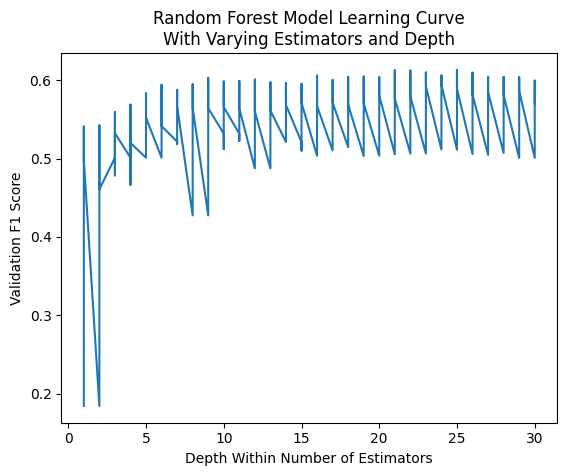

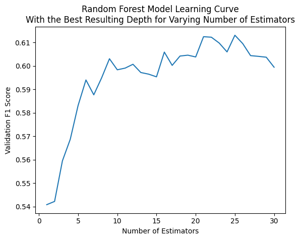

```python
# plot results for random forest classifiers with varying estimators and depth

plt.plot(rf_results['est'], rf_results['result_valid'])
plt.xlabel('Depth Within Number of Estimators')
plt.ylabel('Validation F1 Score')
plt.title('Random Forest Model Learning Curve\nWith Varying Estimators and Depth')
plt.show()
print()

rf_max = pd.DataFrame(rf_results.groupby('est')['result_valid'].max()).reset_index()

plt.plot(rf_max['est'], rf_max['result_valid'])
plt.xlabel('Number of Estimators')
plt.ylabel('Validation F1 Score')
plt.title('Random Forest Model Learning Curve\nWith the Best Resulting Depth for Varying Number of Estimators')
plt.show()
```

The best random forest classifier model I tested with upsampled data had 25 estimators, a depth of 12, and an F1 score of 0.6131. I arbitrarily stopped after 30 estimators and depth of 30. The plot did not indicate an obvious peak, so there might be better models of this type, but F1 score hit something of a plateau after 9 estimators and at least a local peak at 16 estimators. Further improvement is likely to be small and outweighed by increased complexity.

# Test the Model

```python
# Retrain model with combined upsampled training and validation data

features_valid_upsampled, target_valid_upsampled = upsample(features_valid, target_valid, 4)
features_combo = pd.concat([features_upsampled, features_valid_upsampled], ignore_index=True)
target_combo = pd.concat([target_upsampled, target_valid_upsampled], ignore_index=True)

final_rf_model = best_rf_model.fit(features_combo, target_combo)

print("Upsampled Validation Set Class Frequencies:")
display(target_valid_upsampled.value_counts(normalize=True))
print()
print("Combined Upsampled Training and Validation Set Class Frequencies:")
display(target_combo.value_counts(normalize=True))
```

```
Upsampled Validation Set Class Frequencies:
```

```
1    0.502058
0    0.497942
Name: Exited, dtype: float64
```

```
Combined Upsampled Training and Validation Set Class Frequencies:
```

```
1    0.506523
0    0.493477
Name: Exited, dtype: float64
```

```python
# Test final model with the test data set and calculate AUC-ROC

test_score = f1_score(target_test, final_rf_model.predict(features_test))

probs_one = final_rf_model.predict_proba(features_test)[:, 1]
auc_roc = roc_auc_score(target_test, probs_one)

print("Test Results for the Best Model Predicting Beta Bank Customer Exits")
print("Model:", final_rf_model)
print(f"F1 Score: {test_score:.4f}")
print(f"AUC-ROC: {auc_roc:.4f}")
```

```
Test Results for the Best Model Predicting Beta Bank Customer Exits
Model: RandomForestClassifier(max_depth=12, n_estimators=25, random_state=12345)
F1 Score: 0.6119
AUC-ROC: 0.8484
```

```python
# Sanity check the model by comparing it to a random one

rng = np.random.default_rng(seed=12345)
random_predictions = rng.choice([0, 1], size=len(features_test))
probs_one_random = rng.random(len(features_test))

test_score_random = f1_score(target_test, random_predictions)
auc_roc_random = roc_auc_score(target_test, probs_one_random)

print("Test Results for a Random Model")
print(f"F1 Score: {test_score_random:.4f}")
print(f"AUC-ROC: {auc_roc_random:.4f}")
```

```
Test Results for a Random Model
F1 Score: 0.2785
AUC-ROC: 0.4667
```

The results for the final random forest classifier model trained on combined upsampled training and validation data were good. F1 score was 0.6119 and AUC-ROC was 0.8484, which were considerably better than a random model (F1 score = 0.2785, AUC-ROC = 0.4667) and beyond the project F1 threshold of 0.59.

# General Discussion

The purpose of this project was to predict which customers are likely to leave Beta Bank based on demographic and banking data.

After checking the data, changing one data type, and dropping extraneous features and observations with missing values, I encoded and scaled features as appropriate. A fairly severe class imbalance in the target feature Exited (with 80% not exiting) led to poorly perfoming models. Addressing the imbalance by specifying the class_weight parameter and upsampling the data, I found that upsampling produced the best models. Among decision tree, random forest, and logistic regression models, random forest classifiers consistently performed the best. I optimized the number of estimators and max tree depth parameters to obtain an adequate random forest classifier with 25 estimators and a depth of 12. The final model performed well on the test set with an F1 score of 0.61 and AUC-ROC of 0.85, handily outperforming both a sanity check random model and the project F1 threshold of 0.59.

The final model is not extremely strong, but its adequate F1 score ensures that it balances precision and recall to predict bank exits fairly well. It should provide a good basis for identifying customers that might be on the verge of leaving. Beta Bank should reach out and offer enticements to those customers to reduce churn.